# 协整分析&误差修正模型

### **单整的概念：**

- 如果序列平稳，说明序列不存在单位根，则称序列为零阶单整序列。
- 如果一个序列至少经过d阶差分实现平稳，说明序列存在d个单位根，则称 原序列为d阶单整序列。

### **协整关系的定义:**

假定自变量序列$x_{1t},x_{2t},...,x_{kt}$和相应变量序列$y_t$均为 **非平稳序列**，构造回归模型
$$y_t = \beta_0 + \sum_{i=1}^k\beta_ix_{it}+\epsilon_t$$
假定回归残差序列$\epsilon_t$平稳，我们称相应序列$y_t$与自变量序列之间具有协整关系。

### 协整检验

- 假设条件
  - 原假设：多元非平稳序列之间不存在协整关系
    $$H_0:\epsilon_t \sim I(k),k>=1$$
  - 备择假设：多元非平稳序列之间存在协整关系
    $$H_0:\epsilon_t \sim I(0）$$
- 检验步骤
  - 检验时间序列是否同阶单整，若是，进一步
  - 建立相应序列和输入序列之间的回归模型
  - 对回归残差序列进行平稳型检验
  - 若平稳，还有进行伪回归检验dwtest
  - 进一步，可以建立误差修正模型

### 误差修正模型

协整模型度量序列之间的长期均衡关系，而ECM模型则解释序列的短期波动关系。

响应序列的当期波动主要会收到三方面短期波动的影响：

- 输入序列的当期波动$\Delta x_t$
- 上一期的误差$ECM_{t-1}$
- 纯随机波动$\epsilon_t$

## 协整检验

### 一, 协整检验——E-G检验

1. 两变量的Engle-Granger检验

为了检验两序列$Y_t$与$X_t$是否为协整，Engle和Granger于 1987年提出两步检验法，也称为E-G检验。

第一步：用OLS方法估计方程$Y_t = \alpha_0 + \alpha_1X_t +\epsilon_t$ 并计算非均衡误差，得到:
$$\hat Y_t = \hat \alpha_0 +\hat \alpha_1X_1$$
$$\hat \epsilon_t = Y_t - \hat Y_t$$
称为协整回归(cointegrating)或静态回归(static regression)。

- 第二步，检验$\hat \epsilon_t$的单整性。如果$\hat \epsilon_t$为平稳序列 ，则认为序列$Y_t$与$X_t$存在协整关系，记为CI(1,1); 如果$\hat \epsilon_t$为I(d)序列，则认为序列Yt与Xt存在协整 关系, 记为CI(d,d) 。

## 伪回归

如果$x_t$和$y_t$都是I(1)序列但是独立，回归结果也可能很显著

```r
set.seed(110)
n <- 500
x <- cumsum(rnorm(n))
y <- cumsum(rnorm(n))*2
lmr <- lm(y ~ x)
summary(lmr)
```

```
##
## Call:
## lm(formula = y ~ x)
##
## Residuals:
##      Min       1Q   Median       3Q      Max
## -29.1795  -8.6775   0.0375   8.8982  25.6600
##
## Coefficients:
##             Estimate Std. Error t value Pr(>|t|)
## (Intercept)  2.49701    0.81992   3.045  0.00245 **
## x            0.46871    0.02554  18.350  < 2e-16 ***
## ---
## Signif. codes:  0 '***' 0.001 '**' 0.01 '*' 0.05 '.' 0.1 ' ' 1
##
## Residual standard error: 11.51 on 498 degrees of freedom
## Multiple R-squared:  0.4034, Adjusted R-squared:  0.4022
## F-statistic: 336.7 on 1 and 498 DF,  p-value: < 2.2e-16
```

```r
fUnitRoots::adfTest(residuals(lmr), lags=1, type="c")
```

```
##
## Title:
##  Augmented Dickey-Fuller Test
##
## Test Results:
##   PARAMETER:
##     Lag Order: 1
##   STATISTIC:
##     Dickey-Fuller: -1.3595
##   P VALUE:
##     0.5525
##
## Description:
##  Mon Mar  8 21:21:36 2021 by user:
```

结果显示回归残差有单位根。 这样的回归称为虚假回归。 两者不应该有线性关系。

## 例子

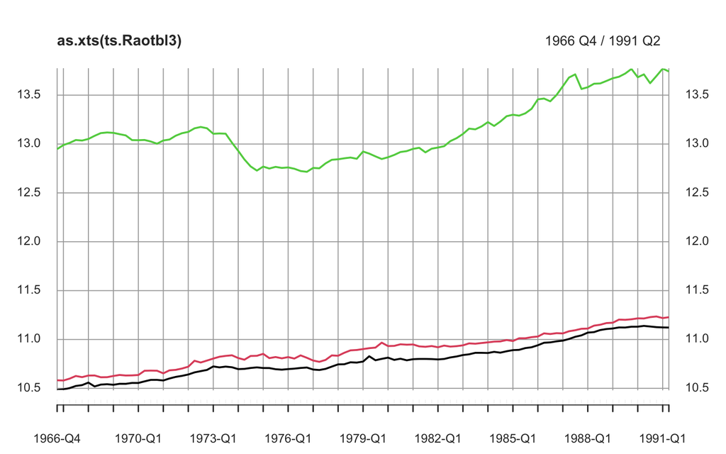

```r
library(urca, quietly = TRUE)
data(Raotbl3)
ts.Raotbl3 <- ts(Raotbl3[,1:3], start=c(1966,4), frequency=4)
library(quantmod, quietly = TRUE)
plot(as.xts(ts.Raotbl3), type="l",
     multi.panel=FALSE, theme="white",
     major.ticks="years",
     grid.ticks.on = "years")
```

做adf单位根检验：

```r
fUnitRoots::adfTest(Raotbl3$lc, lags=1, type="ct")
```

```
##
## Title:
##  Augmented Dickey-Fuller Test
##
## Test Results:
##   PARAMETER:
##     Lag Order: 1
##   STATISTIC:
##     Dickey-Fuller: -1.378
##   P VALUE:
##     0.8341
##
## Description:
##  Mon Mar  8 21:21:36 2021 by user:
```

```r
fUnitRoots::adfTest(Raotbl3$li, lags=1, type="ct")
```

```
##
## Title:
##  Augmented Dickey-Fuller Test
##
## Test Results:
##   PARAMETER:
##     Lag Order: 1
##   STATISTIC:
##     Dickey-Fuller: -2.0159
##   P VALUE:
##     0.57
##
## Description:
##  Mon Mar  8 21:21:36 2021 by user:
```

```r
fUnitRoots::adfTest(Raotbl3$lw, lags=1, type="ct")
```

```
##
## Title:
##  Augmented Dickey-Fuller Test
##
## Test Results:
##   PARAMETER:
##     Lag Order: 1
##   STATISTIC:
##     Dickey-Fuller: -1.0153
##   P VALUE:
##     0.9318
##
## Description:
##  Mon Mar  8 21:21:36 2021 by user:
```

```r
#结果不显著，说明每一个时间序列都有单位根
#检验其一阶差分的平稳性
fUnitRoots::adfTest(diff(Raotbl3$lc), lags=1, type="c")
```

```
##
## Title:
##  Augmented Dickey-Fuller Test
##
## Test Results:
##   PARAMETER:
##     Lag Order: 1
##   STATISTIC:
##     Dickey-Fuller: -6.311
##   P VALUE:
##     0.01
##
## Description:
##  Mon Mar  8 21:21:36 2021 by user:
```

```r
fUnitRoots::adfTest(diff(Raotbl3$li), lags=1, type="c")
```

```
##
## Title:
##  Augmented Dickey-Fuller Test
##
## Test Results:
##   PARAMETER:
##     Lag Order: 1
##   STATISTIC:
##     Dickey-Fuller: -7.0434
##   P VALUE:
##     0.01
##
## Description:
##  Mon Mar  8 21:21:36 2021 by user:
```

```r
fUnitRoots::adfTest(diff(Raotbl3$lw), lags=1, type="c")
```

```
##
## Title:
##  Augmented Dickey-Fuller Test
##
## Test Results:
##   PARAMETER:
##     Lag Order: 1
##   STATISTIC:
##     Dickey-Fuller: -5.9831
##   P VALUE:
##     0.01
##
## Description:
##  Mon Mar  8 21:21:36 2021 by user:
```

```r
#其一阶差分平稳，一阶单整，I(1)序列，说明可以进行协整分析
#urca包的ur.df()函数可以检验差分的阶数，并可以对非随机趋势的类型进行检验
#来检验消费lc与收入li是否存在协整关系。将lc对li作一元回归
##拟合长期协整关系
eglm1 <- lm(lc~li, data=Raotbl3);summary(eglm1)
```

```
##
## Call:
## lm(formula = lc ~ li, data = Raotbl3)
##
## Residuals:
##       Min        1Q    Median        3Q       Max
## -0.065949 -0.016067  0.001839  0.017844  0.057295
##
## Coefficients:
##             Estimate Std. Error t value Pr(>|t|)
## (Intercept) -0.18007    0.14399  -1.251    0.214
## li           1.00731    0.01322  76.203   <2e-16 ***
## ---
## Signif. codes:  0 '***' 0.001 '**' 0.01 '*' 0.05 '.' 0.1 ' ' 1
##
## Residual standard error: 0.02379 on 97 degrees of freedom
## Multiple R-squared:  0.9836, Adjusted R-squared:  0.9834
## F-statistic:  5807 on 1 and 97 DF,  p-value: < 2.2e-16
```

```r
##误差修正模型(ECM 短期波动)
re.lm1=resid(eglm1)
dlc=diff(Raotbl3$lc)
dli=diff(Raotbl3$li)
error.term=head(re.lm1,-1)
data.ecm=data.frame(dy=dlc,dx=dli,error.term=error.term)
model.ecm=lm(dy~dx+error.term,data=data.ecm)
summary(model.ecm)
```

```
##
## Call:
## lm(formula = dy ~ dx + error.term, data = data.ecm)
##
## Residuals:
##       Min        1Q    Median        3Q       Max
## -0.045940 -0.006463  0.001252  0.006792  0.045121
##
## Coefficients:
##              Estimate Std. Error t value Pr(>|t|)
## (Intercept)  0.004621   0.001412   3.273 0.001486 **
## dx           0.289100   0.080803   3.578 0.000548 ***
## error.term  -0.076876   0.061512  -1.250 0.214454
## ---
## Signif. codes:  0 '***' 0.001 '**' 0.01 '*' 0.05 '.' 0.1 ' ' 1
##
## Residual standard error: 0.01296 on 95 degrees of freedom
## Multiple R-squared:  0.1197, Adjusted R-squared:  0.1012
## F-statistic: 6.461 on 2 and 95 DF,  p-value: 0.002339
```

```r
#伪回归检验
library(lmtest)
dwtest(model.ecm)#DW=2.4059 p=0.9762 不是伪回归 模型合理
```

```
##
##  Durbin-Watson test
##
## data:  model.ecm
## DW = 2.4059, p-value = 0.9762
## alternative hypothesis: true autocorrelation is greater than 0
```

```r
Box.test(model.ecm$residuals)#残差不是白噪声
```

```
##
##  Box-Pierce test
##
## data:  model.ecm$residuals
## X-squared = 4.127, df = 1, p-value = 0.0422
```

结果中的模型显著性检验(F检验)不可信，因为回归模型是
$$lc=-0.18+1.01li+e_t$$
所以
$$lc-1.01li = -0.18+e_t$$
即$(lc,li)^T$的协整向量为$(1,-1.01)$。 不考虑自由度调整问题，直接作ADF检验，但其p值是不准确的，需要使用修改后的临界值。

```r
fUnitRoots::adfTest(residuals(eglm1),lags=1,type='c')
```

```
##
## Title:
##  Augmented Dickey-Fuller Test
##
## Test Results:
##   PARAMETER:
##     Lag Order: 1
##   STATISTIC:
##     Dickey-Fuller: -2.6351
##   P VALUE:
##     0.09127
##
## Description:
##  Mon Mar  8 21:21:36 2021 by user:
```

Phillips and Ouliaris给出了利用回归残差进行协整检验的方法， 包含两种方法， **方差比方法**和**多元迹统计量**方法。 R扩展包urca的ca.po()可以用来计算Phillips-Ouliaris检验。 选项demean=“constant”指定有确定性常数趋势， demean=“trend”指定有确定性线性趋势， 缺省为demean=“none”，没有确定性趋势（无漂移）。 选项type=“Pu”指定使用方差比方法， 选项type=“Pz”指定使用多元迹方法， 多元迹方法对哪个分量作为回归因变量不敏感。

检验消费与收入之间的协整:

```r
library(urca,quietly = T)
summary(ca.po(Raotbl3[-c(1:2),c("lc","li")],type='Pz', demean="constant"))
```

```
##
## ########################################
## # Phillips and Ouliaris Unit Root Test #
## ########################################
##
## Test of type Pz
## detrending of series with constant only
##
## Response lc :
##
## Call:
## lm(formula = lc ~ zr)
##
## Residuals:
##       Min        1Q    Median        3Q       Max
## -0.047772 -0.007401  0.001410  0.008169  0.048541
##
## Coefficients:
##             Estimate Std. Error t value Pr(>|t|)
## (Intercept)  0.01183    0.08952   0.132    0.895
## zrlc         1.01799    0.05960  17.080   <2e-16 ***
## zrli        -0.01831    0.06074  -0.302    0.764
## ---
## Signif. codes:  0 '***' 0.001 '**' 0.01 '*' 0.05 '.' 0.1 ' ' 1
##
## Residual standard error: 0.01393 on 93 degrees of freedom
## Multiple R-squared:  0.9941, Adjusted R-squared:  0.994
## F-statistic:  7844 on 2 and 93 DF,  p-value: < 2.2e-16
##
##
## Response li :
##
## Call:
## lm(formula = li ~ zr)
##
## Residuals:
##       Min        1Q    Median        3Q       Max
## -0.036705 -0.011532 -0.000549  0.008860  0.053870
##
## Coefficients:
##             Estimate Std. Error t value Pr(>|t|)
## (Intercept)  0.09644    0.10642   0.906    0.367
## zrlc         0.33183    0.07085   4.683  9.6e-06 ***
## zrli         0.66298    0.07220   9.182  1.1e-14 ***
## ---
## Signif. codes:  0 '***' 0.001 '**' 0.01 '*' 0.05 '.' 0.1 ' ' 1
##
## Residual standard error: 0.01656 on 93 degrees of freedom
## Multiple R-squared:  0.9914, Adjusted R-squared:  0.9912
## F-statistic:  5334 on 2 and 93 DF,  p-value: < 2.2e-16
##
##
##
## Value of test-statistic is: 39.7042
##
## Critical values of Pz are:
##                   10pct    5pct    1pct
## critical values 47.5877 55.2202 71.9273
```

零假设是没有存在协整关系， 0.05水平的右侧临界值为55.2， 统计量值为39.7， 没有超过临界值， 不拒绝零假设， 认为消费与收入不存在协整关系。 这也可能是PO方法的检验功效不足的问题。

Phillips Ouliaris协整检验在多元时不能用来确定多个独立的协整向量， 这需要利用VECM模型。

R扩展包urca提供了多种协整检验， 除了Phillips-Ouliaris协整检验， 还可以进行Johansen的迹和最大特征值检验。

R扩展包tsDyn提供了Johansen的协整检验， 并可以用AIC或BIC进行秩滞后值选择。

R扩展包CommonTrend可以从协整系统中提取共同的趋势， 并绘图。

R扩展包cointReg提供了协整的回归参数估计、推断功能。

R扩展包vars提供了VAR、VECM、结构VAR(SVAR)等模型的估计、检验， 因果性检验和协整检验的功能。

这里主要讨论从VAR模型的角度定义协整。

## 多变量协整关系的检验——拓展的E-G检验

多变量协整关系的检验要比双变量复杂一些，主要 在于协整变量间可能存在多种平稳的线性组合。

假设有四个I(1)变量,Z,X,Y,W，他们有如下的均衡关系:
$$Z_t=\alpha_0+\alpha_1W_t+\alpha_2X_t+\alpha_3Y_t+\mu_t$$
非均衡误差项$\mu_t$应该是I(0)序列：

$$\mu_t=Z_0-\alpha_0-\alpha_1W_t-\alpha_2X_t-\alpha_3Y_t$$
**检验步骤:**

- 对于多变量的协整检验过程，基本与双变量情形相同，即需检验变量是否具有同阶单整性，以及是否 存在平稳的线性组合。
- 在检验是否存在平稳的线性组合时，需通过设置一个变量为被解释变量，其他变量为解释变量，进行 OLS估计并检验残差序列是否平稳。
- 如果不平稳，则需更换被解释变量，进行同样的OLS估计及相应的残差项检验。
- 当所有的变量都被作为被解释变量检验之后，仍不能得到平稳的残差项序列，则认为这些变量间不存 在(d,d)阶协整。

**检验残差项是否平稳的DF与ADF检验临界值 要比通常的DF与ADF检验临界值小，而且该 临界值还受到所检验的变量个数的影响。**

### 课后练习：

查找国内生产总值、居民消费总额、政府消费总额、资本形成总额、国际贸易总额等，并尝试对其建立协整模型，并尝试分析GDP的主要影响因素。

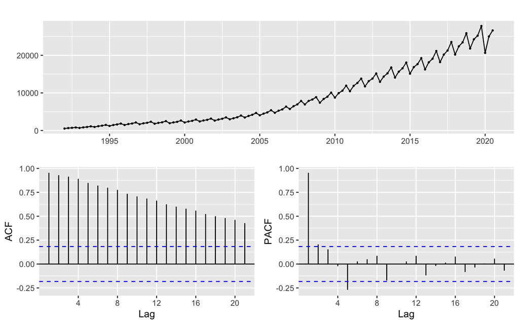

```r
#建立gdp和出口，政府支出的协整
#首先，建立单变量协整
gdp %>% ggtsdisplay()
```

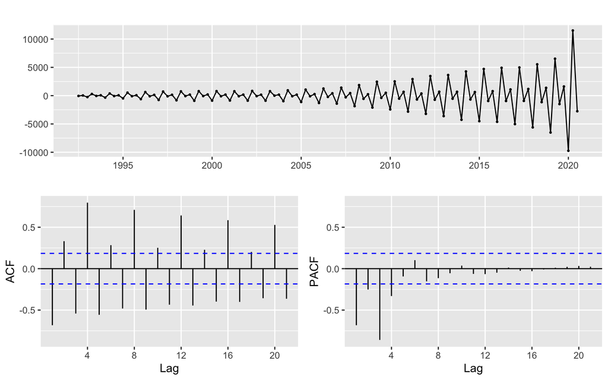

```r
gdp %>% diff() %>% diff() %>% ggtsdisplay()
```

```r
ar(gdp %>% diff() %>% diff())
```

```
##
## Call:
## ar(x = gdp %>% diff() %>% diff())
##
## Coefficients:
##       1        2        3        4
## -1.3549  -1.3123  -1.2136  -0.3303
##
## Order selected 4  sigma^2 estimated as  744793
```

```r
library(urca)
library(tseries)
#检验是否是二阶单整
fUnitRoots::adfTest(diff(diff(gdp)),lags=4) #二阶单整
```

```
##
## Title:
##  Augmented Dickey-Fuller Test
##
## Test Results:
##   PARAMETER:
##     Lag Order: 4
##   STATISTIC:
##     Dickey-Fuller: -7.9064
##   P VALUE:
##     0.01
##
## Description:
##  Mon Mar  8 21:21:37 2021 by user:
```

```r
kpss.test(diff(diff(gdp))) #二阶单整
```

```
##
##  KPSS Test for Level Stationarity
##
## data:  diff(diff(gdp))
## KPSS Level = 0.019017, Truncation lag parameter = 4, p-value = 0.1
```

```r
pp.test(diff(diff(gdp))) #  二阶单整
```

```
##
##  Phillips-Perron Unit Root Test
##
## data:  diff(diff(gdp))
## Dickey-Fuller Z(alpha) = -166.94, Truncation lag parameter = 4, p-value
## = 0.01
## alternative hypothesis: stationary
```

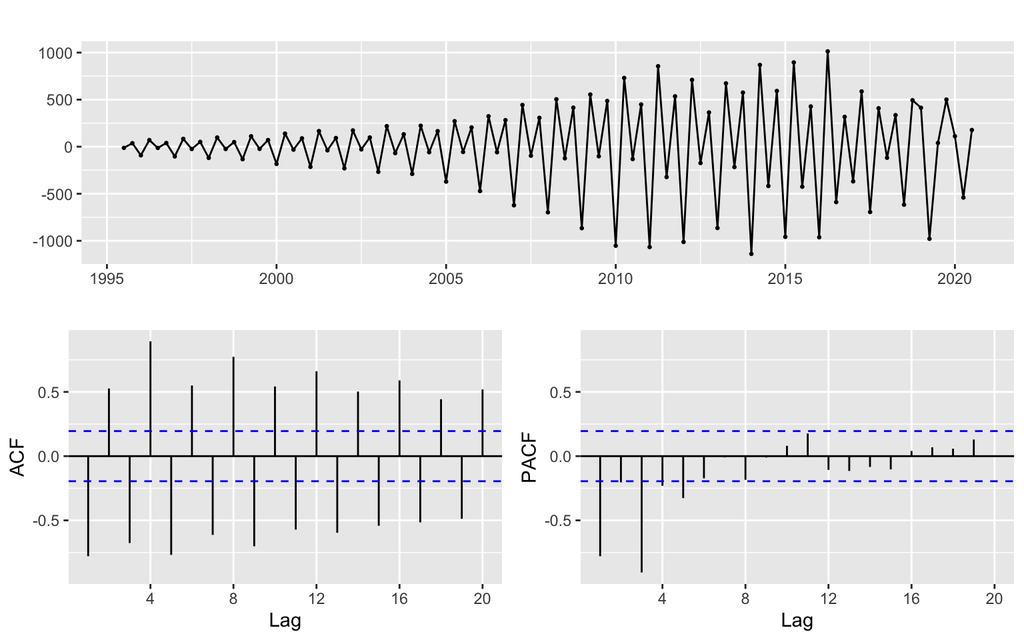

```r
#下面检验政府支出和出口额是否同阶单整
government_outcome %>% diff() %>% diff() %>% ggtsdisplay()
```

```r
ar(government_outcome%>% diff() %>% diff())
```

```
##
## Call:
## ar(x = government_outcome %>% diff() %>% diff())
##
## Coefficients:
##       1        2        3        4        5        6
## -1.4631  -1.7909  -1.8611  -0.9544  -0.5689  -0.1724
##
## Order selected 6  sigma^2 estimated as  13218
```

```r
fUnitRoots::adfTest(government_outcome %>% diff() %>% diff(),lags=6) #结果显著，说明二阶单整
```

```
##
## Title:
##  Augmented Dickey-Fuller Test
##
## Test Results:
##   PARAMETER:
##     Lag Order: 6
##   STATISTIC:
##     Dickey-Fuller: -6.6149
##   P VALUE:
##     0.01
##
## Description:
##  Mon Mar  8 21:21:38 2021 by user:
```

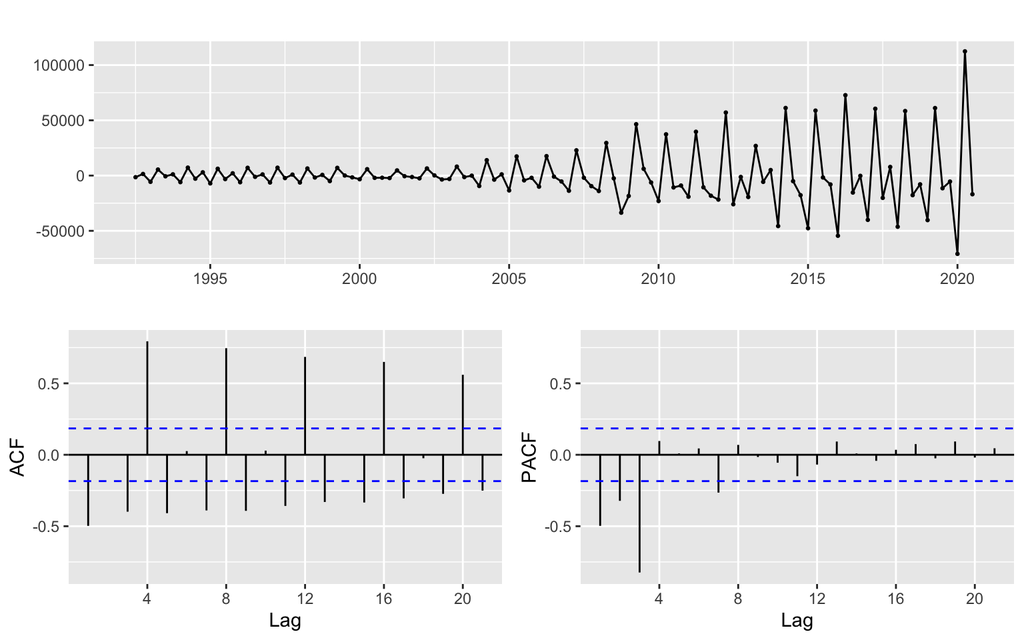

```r
chukou %>% diff() %>% diff() %>% ggtsdisplay()
```

```r
ar(chukou%>% diff() %>% diff())
```

```
##
## Call:
## ar(x = chukou %>% diff() %>% diff())
##
## Coefficients:
##       1        2        3        4        5        6        7
## -0.8334  -0.7662  -0.6584  -0.0456  -0.1595  -0.1796  -0.2649
##
## Order selected 7  sigma^2 estimated as  139258699
```

```r
fUnitRoots::adfTest(chukou %>% diff() %>% diff(),lags=7) #结果显著，说明二阶单整
```

```
##
## Title:
##  Augmented Dickey-Fuller Test
##
## Test Results:
##   PARAMETER:
##     Lag Order: 7
##   STATISTIC:
##     Dickey-Fuller: -5.2765
##   P VALUE:
##     0.01
##
## Description:
##  Mon Mar  8 21:21:38 2021 by user:
```